# Conceptos en tres debates previsionales

Resultados descriptivos preliminares de la ronda de anotaciones

## Pregunta y alcance

¿Qué conceptos aparecen en cada ley y qué posturas se registran sobre ellos? Este informe compara las leyes 21.419, 21.538 y 21.735 con el mismo libro de códigos. La unidad para los porcentajes es la **intervención sustantiva**: una intervención cuenta una sola vez por concepto aunque tenga varios bloques o menciones. Una intervención puede mencionar varios conceptos, por lo que los porcentajes de una ley pueden sumar más de 100 %.

La red de congruencia se limita a la Ley 21.735. Esta versión de entrega presenta cuatro resultados: la cobertura de intervenciones, el perfil de conceptos por ley, la tabla de posturas y una red exploratoria. El análisis de comunidades se reserva para una siguiente versión.

## Preparación

Cada bloque de código realiza un paso que se puede ejecutar y revisar por separado. Las tablas y figuras se escriben en una ruta fija y se reemplazan en cada ejecución.

```r
pacman::p_load(arrow, dplyr, tidyr, stringr, ggplot2,
               jsonlite, knitr, scales, tibble, ggrepel,
               flextable, officer)
source("R/apa7_word_table.R")

INPUT_DIR <- "data/proc_data/annotations_inputs/pilot_d4e0291b4df3fc0f5343"
RESULT_DIR <- "output/annotations/openai_gpt6luna_20261002"
OUTPUT_DIR <- "output/analysis/concepts"
FIGURE_DIR <- file.path(OUTPUT_DIR, "figures")
dir.create(FIGURE_DIR, recursive = TRUE, showWarnings = FALSE)
knitr::opts_chunk$set(fig.path = paste0(FIGURE_DIR, "/"))
theme_set(theme_minimal(base_size = 12))

law_names <- c("21419" = "Ley 21.419", "21538" = "Ley 21.538",
               "21735" = "Ley 21.735")
stage_levels <- c("Primer Trámite Constitucional",
                  "Segundo Trámite Constitucional",
                  "Tercer Trámite Constitucional")
```

Leemos el censo congelado, las respuestas combinadas y el libro de códigos. Exigimos una respuesta completa por bloque y el mismo identificador en ambas tablas. Esta comprobación verifica la combinación de archivos, no la exactitud semántica de las anotaciones.

```r
sample_blocks <- arrow::read_parquet(file.path(INPUT_DIR, "sample.parquet")) |>
  mutate(across(c(unit_id, utterance_id, document_uri, law_number), as.character))
result_index <- arrow::read_parquet(file.path(RESULT_DIR, "results.parquet")) |>
  mutate(across(c(unit_id, law_number, provider), as.character))
annotation_rows <- arrow::read_parquet(file.path(RESULT_DIR, "annotations.parquet")) |>
  mutate(across(c(unit_id, law_number, concept_id), as.character))
codebook <- jsonlite::fromJSON(file.path(INPUT_DIR, "codebook.json"))
concepts <- as_tibble(codebook$concepts) |>
  transmute(concept_id = id, concept_label = label,
            short_label = str_wrap(label, width = 25))

stopifnot(nrow(sample_blocks) == 3609L,
          nrow(result_index) == nrow(sample_blocks),
          !anyDuplicated(sample_blocks$unit_id),
          !anyDuplicated(result_index$unit_id),
          !anyDuplicated(result_index$sample_index),
          identical(sort(result_index$sample_index),
                    seq.int(0L, nrow(sample_blocks) - 1L)),
          identical(result_index$unit_id[order(result_index$sample_index)],
                    sample_blocks$unit_id),
          identical(sort(sample_blocks$unit_id), sort(result_index$unit_id)),
          all(result_index$status == "completed"),
          all(annotation_rows$unit_id %in% result_index$unit_id),
          all(annotation_rows$concept_id %in% concepts$concept_id))

annotation_provenance <- annotation_rows |>
  select(unit_id, provider, model_requested) |>
  left_join(result_index |>
              select(unit_id, expected_provider = provider,
                     expected_model = model_requested), by = "unit_id")
stopifnot(all(annotation_provenance$provider ==
                annotation_provenance$expected_provider),
          all(annotation_provenance$model_requested ==
                annotation_provenance$expected_model))

source_metadata <- sample_blocks |>
  select(unit_id, law_number, document_uri, utterance_id) |>
  left_join(result_index |>
              select(unit_id, result_law = law_number,
                     result_document = document_uri,
                     result_utterance = utterance_id), by = "unit_id")
stopifnot(all(source_metadata$law_number == source_metadata$result_law),
          all(source_metadata$document_uri == source_metadata$result_document),
          all(source_metadata$utterance_id == source_metadata$result_utterance))

blocks <- sample_blocks |>
  select(unit_id, law_number, document_uri, utterance_id,
         constitutional_stage) |>
  left_join(result_index |>
              select(unit_id, status, provider, quality_flags), by = "unit_id") |>
  mutate(substantive = !str_detect(coalesce(quality_flags, ""),
                                  '"(?:vote|procedural)"'),
         law = factor(law_names[law_number], levels = unname(law_names)),
         stage = factor(constitutional_stage, levels = stage_levels))
```

Se cuentan bloques para describir la procedencia de las anotaciones. Los porcentajes analíticos usarán intervenciones, calculadas después.

El censo contiene 3609 bloques, todos anotados por `gpt-6-luna` en OpenAI con los mismos requests congelados. Los 2.813 bloques anotados el 22-09 se reutilizaron; los 796 que en esa fecha se habían anotado en Bedrock se volvieron a anotar en OpenAI, de modo que la procedencia del modelo no coincide con ningún trámite.

## Intervenciones incluidas y descartadas

El denominador incluye todas las intervenciones con al menos un bloque sustantivo, también aquellas sin conceptos anotados. Una intervención se descarta solo si **todos** sus bloques están marcados como votación o procedimiento. Distinguimos los descartes por votación, por procedimiento y por ambas marcas; estas categorías son excluyentes. La clave compuesta evita mezclar intervenciones de documentos o leyes diferentes.

```r
interventions <- blocks |>
  filter(substantive) |>
  distinct(law_number, document_uri, utterance_id, law, stage)
intervention_audit <- blocks |>
  group_by(law_number, document_uri, utterance_id, law, stage) |>
  summarise(included = any(substantive),
            vote = any(str_detect(coalesce(quality_flags, ""), '"vote"')),
            procedural = any(str_detect(coalesce(quality_flags, ""),
                                        '"procedural"')),
            .groups = "drop") |>
  mutate(reason = case_when(
    included ~ "included",
    vote & procedural ~ "both",
    vote ~ "vote",
    procedural ~ "procedural"
  ))
stopifnot(!anyNA(intervention_audit$reason))

denominator_table <- intervention_audit |>
  group_by(law, stage) |>
  summarise(total = n(), descartadas = sum(!included),
            sustantivas = sum(included), .groups = "drop") |>
  arrange(law, stage)
denominators <- denominator_table |>
  transmute(law, stage, intervenciones = sustantivas)
stopifnot(sum(denominator_table$sustantivas) == nrow(interventions),
          all(denominator_table$total == denominator_table$descartadas +
                denominator_table$sustantivas))

knitr::kable(denominator_table,
             col.names = c("Ley", "Trámite", "Total", "Descartadas",
                           "Sustantivas"),
             caption = "Intervenciones incluidas y descartadas por ley y trámite")
```

Intervenciones incluidas y descartadas por ley y trámite

| Ley | Trámite | Total | Descartadas | Sustantivas |
| --- | --- | --- | --- | --- |
| Ley 21.419 | Primer Trámite Constitucional | 55 | 18 | 37 |
| Ley 21.419 | Segundo Trámite Constitucional | 165 | 110 | 55 |
| Ley 21.419 | Tercer Trámite Constitucional | 42 | 14 | 28 |
| Ley 21.538 | Primer Trámite Constitucional | 80 | 41 | 39 |
| Ley 21.538 | Segundo Trámite Constitucional | 31 | 14 | 17 |
| Ley 21.735 | Primer Trámite Constitucional | 320 | 194 | 126 |
| Ley 21.735 | Segundo Trámite Constitucional | 209 | 143 | 66 |
| Ley 21.735 | Tercer Trámite Constitucional | 194 | 55 | 139 |

Los totales son 120, 56 y 331 intervenciones sustantivas, respectivamente. Se descartaron 589 intervenciones completas. Los denominadores por trámite son pequeños en algunos casos. Las variaciones de varios puntos porcentuales deben leerse junto con estos tamaños.

La misma tabla se exporta a Word con el estilo de reglas horizontales, tipografía y espaciado de los materiales de replicación.

```r
denominator_word <- denominator_table |>
  mutate(stage = recode(as.character(stage),
                        `Primer Trámite Constitucional` = "Primero",
                        `Segundo Trámite Constitucional` = "Segundo",
                        `Tercer Trámite Constitucional` = "Tercero")) |>
  setNames(c("Ley", "Trámite", "Total", "Descartadas", "Sustantivas"))
export_apa7_word_table(
  denominator_word,
  path = file.path(OUTPUT_DIR, "denominadores_apa7.docx"),
  title = "Intervenciones incluidas y descartadas por ley y trámite",
  note = paste("Se descartan las intervenciones compuestas solo por bloques",
               "de votación o procedimiento, o ambos. Sustantivas =",
               "intervenciones con al menos un bloque sustantivo."),
  left_columns = 2L,
  column_widths = c(1.15, 1.2, 0.75, 1.55, 1.55)
)
```

## Perfiles de conceptos por ley

Una misma intervención puede contener varios bloques con el mismo concepto. Se reduce cada combinación intervención–concepto a una presencia y luego se divide por el número de intervenciones de su ley y trámite.

```r
concept_presence <- annotation_rows |>
  inner_join(blocks |>
               filter(substantive) |>
               select(unit_id, law, stage), by = "unit_id") |>
  distinct(law_number, document_uri, utterance_id, law, stage, concept_id)

law_totals <- interventions |>
  count(law, name = "intervenciones")
prevalence_law <- concept_presence |>
  count(law, concept_id, name = "intervenciones_con_concepto") |>
  complete(law, concept_id = concepts$concept_id,
           fill = list(intervenciones_con_concepto = 0L)) |>
  left_join(law_totals, by = "law") |>
  mutate(proporcion = intervenciones_con_concepto / intervenciones) |>
  left_join(concepts, by = "concept_id")

stopifnot(all(prevalence_law$proporcion >= 0),
          all(prevalence_law$proporcion <= 1))
```

### Comparación entre leyes

La figura sigue el boceto: los conceptos ocupan posiciones categóricas en X, cada ley es una línea y los puntos son proporciones observadas. El orden de conceptos sigue su frecuencia total en el corpus. Las líneas facilitan comparar perfiles; la distancia horizontal y la pendiente no representan tiempo ni una escala conceptual continua.

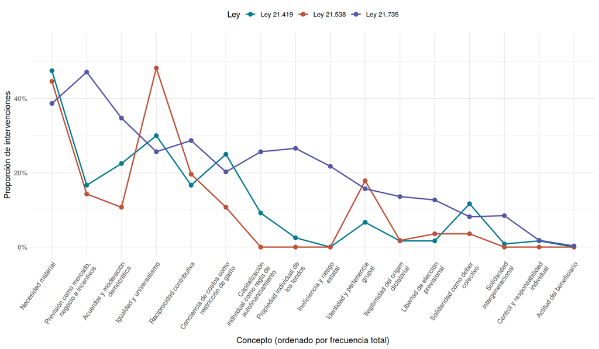

Figura 1: Proporción de intervenciones sustantivas que mencionan cada concepto, por ley

```r
concept_order <- concept_presence |>
  count(concept_id, sort = TRUE) |>
  pull(concept_id)
concept_order <- c(concept_order, setdiff(concepts$concept_id, concept_order))
plot_law <- prevalence_law |>
  mutate(concept_id = factor(concept_id, levels = concept_order))

perfiles_por_ley <- ggplot(plot_law,
                aes(x = concept_id, y = proporcion, color = law, group = law)) +
  geom_line(linewidth = 0.9) +
  geom_point(size = 2.5) +
  scale_x_discrete(labels = setNames(concepts$short_label, concepts$concept_id)) +
  scale_y_continuous(labels = label_percent(accuracy = 1), limits = c(0, 0.55)) +
  scale_color_manual(values = c("#007C91", "#C0523A", "#5658A6")) +
  labs(x = "Concepto (ordenado por frecuencia total)",
       y = "Proporción de intervenciones", color = "Ley") +
  theme(axis.text.x = element_text(angle = 55, hjust = 1, vjust = 1),
        legend.position = "top")
print(perfiles_por_ley)
ggsave(file.path(FIGURE_DIR, "perfiles_por_ley.png"), perfiles_por_ley,
       width = 12, height = 7, dpi = 180)
```

La lectura puntual de cualquier marca es «en esta ley, este porcentaje de intervenciones sustantivas mencionó el concepto». El orden de los conceptos de mayor presencia puede cambiar cuando se revisen las anotaciones.

En la Ley 21.419 predomina necesidad material (47.5%); en la 21.538, igualdad y universalismo (48.2%); y en la 21.735, previsión como mercado (47.1%). Estas son diferencias de presencia dentro del corpus anotado. Una proporción alta muestra difusión entre intervenciones, sin medir intensidad argumentativa, adhesión al concepto ni importancia normativa.

### Posturas por concepto y ley

La presencia anterior reúne apoyos y objeciones. Para distinguirlos, contamos una sola vez cada combinación intervención–concepto–postura, aunque aparezca en varios bloques. En cada celda, el porcentaje positivo o negativo usa como denominador la suma de los dos recuentos de postura para ese concepto y ley. Una intervención con ambas posturas contribuye una vez a cada recuento.

```r
stance_presence <- annotation_rows |>
  inner_join(blocks |>
               filter(substantive) |>
               select(unit_id, law), by = "unit_id") |>
  distinct(law_number, document_uri, utterance_id, law, concept_id, stance)

stance_counts <- stance_presence |>
  count(law, concept_id, stance) |>
  complete(law, concept_id = concepts$concept_id,
           stance = c("support", "oppose"), fill = list(n = 0L)) |>
  pivot_wider(names_from = stance, values_from = n) |>
  mutate(total_posturas = support + oppose,
         proporcion_positiva = if_else(total_posturas > 0,
                                      support / total_posturas, NA_real_),
         proporcion_negativa = if_else(total_posturas > 0,
                                      oppose / total_posturas, NA_real_)) |>
  left_join(concepts, by = "concept_id") |>
  group_by(law) |>
  mutate(destacar_positivos = min_rank(desc(support)) <= 3 & support > 0,
         destacar_negativos = min_rank(desc(oppose)) <= 3 & oppose > 0) |>
  ungroup()

mixed_stance_interventions <- stance_presence |>
  count(law, document_uri, utterance_id, concept_id) |>
  summarise(n_ambivalentes = sum(n == 2L), .groups = "drop") |>
  pull(n_ambivalentes)
```

La tabla tiene un concepto por fila y una ley por columna. Cada celda indica `N positivo (porcentaje)` y `N negativo (porcentaje)`. Se destacan en negrita los tres recuentos positivos y negativos más altos de cada ley, con sus empates. El destaque se basa en **N**, mientras que el porcentaje permite comparar el equilibrio de posturas dentro de cada concepto. Hay 40 combinaciones intervención–concepto con ambas posturas en el corpus.

```r
stance_cells <- stance_counts |>
  mutate(positive = if_else(
           destacar_positivos,
           sprintf("<strong>+ %d (%.1f%%)</strong>",
                   support, 100 * proporcion_positiva),
           sprintf("+ %d (%.1f%%)", support, 100 * proporcion_positiva)),
         negative = if_else(
           destacar_negativos,
           sprintf("<strong>− %d (%.1f%%)</strong>",
                   oppose, 100 * proporcion_negativa),
           sprintf("− %d (%.1f%%)", oppose, 100 * proporcion_negativa)),
         cell = if_else(total_posturas == 0, "—",
                        paste0(positive, "<br>", negative))) |>
  select(concept_id, concept_label, law, cell) |>
  pivot_wider(names_from = law, values_from = cell) |>
  arrange(match(concept_id, concepts$concept_id)) |>
  select(-concept_id)
knitr::kable(stance_cells, format = "html", escape = FALSE,
             align = c("l", "c", "c", "c"),
             col.names = c("Concepto", unname(law_names)),
             caption = "Intervenciones con apoyo y oposición por concepto y ley")
```

Intervenciones con apoyo y oposición por concepto y ley

| Concepto | Ley 21.419 | Ley 21.538 | Ley 21.735 |
| --- | --- | --- | --- |
| Capitalización individual como regla de autofinanciamiento | + 3 (27.3%) **− 8 (72.7%)** | — | + 44 (51.8%) **− 41 (48.2%)** |
| Propiedad individual de los fondos | + 3 (100.0%) − 0 (0.0%) | — | + 81 (91.0%) − 8 (9.0%) |
| Reciprocidad contributiva | + 20 (100.0%) − 0 (0.0%) | **+ 11 (100.0%)** − 0 (0.0%) | **+ 95 (100.0%)** − 0 (0.0%) |
| Control y responsabilidad individual | + 1 (50.0%) − 1 (50.0%) | — | + 2 (33.3%) − 4 (66.7%) |
| Actitud del beneficiario | — | — | + 0 (0.0%) − 1 (100.0%) |
| Identidad y pertenencia grupal | + 8 (100.0%) − 0 (0.0%) | + 10 (100.0%) − 0 (0.0%) | + 52 (100.0%) − 0 (0.0%) |
| Necesidad material | **+ 57 (100.0%)** − 0 (0.0%) | **+ 25 (100.0%)** − 0 (0.0%) | **+ 128 (100.0%)** − 0 (0.0%) |
| Igualdad y universalismo | **+ 36 (94.7%)** − 2 (5.3%) | **+ 27 (96.4%)** **− 1 (3.6%)** | + 84 (98.8%) − 1 (1.2%) |
| Conciencia de costos como restricción de gasto | + 14 (43.8%) **− 18 (56.2%)** | + 3 (50.0%) **− 3 (50.0%)** | + 50 (68.5%) − 23 (31.5%) |
| Solidaridad como deber colectivo | + 14 (100.0%) − 0 (0.0%) | + 2 (100.0%) − 0 (0.0%) | + 24 (88.9%) − 3 (11.1%) |
| Solidaridad intergeneracional | + 1 (100.0%) − 0 (0.0%) | — | + 15 (53.6%) − 13 (46.4%) |
| Libertad de elección previsional | + 2 (100.0%) − 0 (0.0%) | + 2 (100.0%) − 0 (0.0%) | + 41 (95.3%) − 2 (4.7%) |
| Ineficiencia y riesgo estatal | — | — | + 45 (57.7%) **− 33 (42.3%)** |
| Previsión como mercado, negocio e incentivos | + 13 (65.0%) **− 7 (35.0%)** | + 3 (37.5%) **− 5 (62.5%)** | + 86 (48.9%) **− 90 (51.1%)** |
| Ilegitimidad del origen dictatorial | + 1 (50.0%) − 1 (50.0%) | + 1 (100.0%) − 0 (0.0%) | + 44 (97.8%) − 1 (2.2%) |
| Acuerdos y moderación democrática | **+ 26 (96.3%)** − 1 (3.7%) | + 6 (100.0%) − 0 (0.0%) | **+ 103 (88.8%)** − 13 (11.2%) |

Exportamos la misma tabla a Word; la negrita conserva la distinción de los recuentos altos de apoyo y oposición dentro de cada ley.

```r
word_concept_labels <- c(
  capitalizacion_individual = "Capitalización individual",
  propiedad_individual_fondos = "Propiedad de fondos",
  reciprocidad_contributiva = "Reciprocidad contributiva",
  control_responsabilidad_individual = "Control individual",
  actitud = "Actitud del beneficiario",
  identidad = "Identidad grupal",
  necesidad_material = "Necesidad material",
  igualdad_universalismo = "Igualdad y universalismo",
  conciencia_costos = "Conciencia de costos",
  solidaridad_previsional_colectiva = "Solidaridad colectiva",
  solidaridad_intergeneracional = "Solidaridad intergeneracional",
  libertad_eleccion_previsional = "Libertad de elección",
  ineficiencia_estado = "Riesgo estatal",
  prevision_como_mercado = "Previsión como mercado",
  ilegitimidad_origen_dictatorial = "Origen dictatorial",
  acuerdos_moderacion = "Acuerdos y moderación"
)
stance_word <- stance_counts |>
  mutate(positive = sprintf("+ %d (%.1f%%)",
                            support, 100 * proporcion_positiva),
         negative = sprintf("− %d (%.1f%%)",
                            oppose, 100 * proporcion_negativa),
         cell = if_else(total_posturas == 0, "—",
                        paste(positive, negative, sep = "\n"))) |>
  transmute(concept_id, concept_label = unname(word_concept_labels[concept_id]),
            law, cell) |>
  pivot_wider(names_from = law, values_from = cell) |>
  arrange(match(concept_id, concepts$concept_id)) |>
  select(-concept_id) |>
  setNames(c("Concepto", unname(law_names)))
stance_emphasis <- stance_counts |>
  filter(total_posturas > 0) |>
  transmute(row = match(concept_id, concepts$concept_id),
            column = match(as.character(law), unname(law_names)) + 1L,
            positive = sprintf("+ %d (%.1f%%)",
                               support, 100 * proporcion_positiva),
            negative = sprintf("− %d (%.1f%%)",
                               oppose, 100 * proporcion_negativa),
            bold_positive = destacar_positivos,
            bold_negative = destacar_negativos)
export_apa7_word_table(
  stance_word,
  path = file.path(OUTPUT_DIR, "posturas_por_concepto_ley_apa7.docx"),
  title = "Posturas sobre cada concepto por ley",
  note = paste("+ = apoyo; − = oposición; % = N/(N+ + N−).",
               "Negrita = tres N mayores por postura y ley, con empates."),
  table_number = 2L, left_columns = 1L,
  max_width = 9.7, landscape = TRUE,
  column_widths = c(3.1, 2.2, 2.2, 2.2),
  body_font_size = 12, cell_padding = 7,
  rich_cells = stance_emphasis
)
```

## Red exploratoria de congruencia

Leifeld describe la proyección de matrices binarias de afiliación y el coseno como normalización de solapamientos (Leifeld 2017). El ejemplo en `example/discourse_networks.R` reduce las menciones repetidas de un actor a un concepto. Aquí se registra por separado si cada actor apoyó o cuestionó un concepto **al menos una vez** en la Ley 21.735. La red une dos conceptos cuando un mismo actor apoyó ambos o cuestionó ambos. Un actor con ambas posturas puede contribuir dos coincidencias al numerador.

Leemos la identidad del hablante por `unit_id` y exigimos un identificador válido para las anotaciones usadas en la red. El análisis reúne los tres trámites de la ley; por ello, una variación de postura entre trámites se conserva como ambivalencia del actor.

```r
speakers <- arrow::read_parquet(
  "data/proc_data/ley_21735/coding_chunks_long.parquet"
) |>
  transmute(unit_id = as.character(unit_id),
            speaker_id = as.character(speaker_id)) |>
  distinct()
network_claims <- annotation_rows |>
  filter(law_number == "21735", stance %in% c("support", "oppose")) |>
  inner_join(blocks |>
               filter(substantive) |>
               select(unit_id), by = "unit_id") |>
  left_join(speakers, by = "unit_id") |>
  filter(!is.na(speaker_id), speaker_id != "") |>
  distinct(speaker_id, concept_id, stance)
ambivalence <- network_claims |>
  count(speaker_id, concept_id) |>
  summarise(pares_con_dos_posturas = sum(n == 2L),
            pares_actor_concepto = n(), .groups = "drop")
```

Hay 46 pares actor–concepto con ambas posturas entre 891 pares observados. Esta ambivalencia impide leer cada vínculo como una adhesión estable del actor.

Construimos matrices binarias actor × concepto para apoyo y oposición. El numerador de congruencia suma los productos correspondientes a posturas iguales. Aplicamos la opción `cosine` **tal como figura en el [exportador Java de DNA](https://github.com/leifeld-lab/dna/blob/master/dna/src/main/java/dna/export/Exporter.java#L1458-L1473)**: dividimos por $\sqrt{d_i^2}\sqrt{d_j^2}=d_i d_j$, donde $d_i=\sum_a(A^+_{ai}+A^-_{ai})$ es la actividad binaria del concepto $i$. Fijamos en cero la diagonal y los pares sin actividad. Esta fórmula del programa difiere del coseno matemático binario que describe el capítulo; la figura usa la implementación de DNA.

```r
actor_ids <- sort(unique(network_claims$speaker_id))
concept_ids <- concepts$concept_id
support <- matrix(0, nrow = length(actor_ids), ncol = length(concept_ids),
                  dimnames = list(actor_ids, concept_ids))
oppose <- support
support_rows <- network_claims |> filter(stance == "support")
oppose_rows <- network_claims |> filter(stance == "oppose")
support[cbind(match(support_rows$speaker_id, actor_ids),
              match(support_rows$concept_id, concept_ids))] <- 1
oppose[cbind(match(oppose_rows$speaker_id, actor_ids),
             match(oppose_rows$concept_id, concept_ids))] <- 1

same_counts <- crossprod(support) + crossprod(oppose)
concept_activity <- colSums(support + oppose)
denominator <- outer(sqrt(concept_activity^2), sqrt(concept_activity^2))
congruence <- same_counts / denominator
congruence[!is.finite(congruence)] <- 0
diag(congruence) <- 0

# Para seleccionar aristas, cada actor cuenta una vez por par de conceptos.
same_actors <- matrix(0L, length(concept_ids), length(concept_ids))
for (i in seq_along(concept_ids)) {
  for (j in seq_along(concept_ids)) {
    same_actors[i, j] <- sum(
      (support[, i] == 1 & support[, j] == 1) |
        (oppose[, i] == 1 & oppose[, j] == 1)
    )
  }
}
stopifnot(all(congruence >= 0 & congruence <= 1),
          isTRUE(all.equal(congruence, t(congruence))),
          all(same_actors <= same_counts))

toy <- matrix(c(1, 1, 1, 0), nrow = 2)
toy_activity <- colSums(toy)
toy_dna_cosine <- crossprod(toy)[1, 2] /
  prod(sqrt(toy_activity^2))
stopifnot(isTRUE(all.equal(toy_dna_cosine, 0.5)))
```

Para que los 16 conceptos estén visibles, mostramos primero los 20 pares compartidos por más actores y añadimos el vínculo más frecuente de cada concepto aún ausente. Un concepto sin vínculo positivo se dibuja aislado. El grosor representa el peso normalizado de DNA. La disposición se fija tomando como referencia la figura exploratoria anterior para separar las dos zonas del debate y facilitar la lectura; **las distancias entre nodos no son una medida estadística**.

```r
pairs <- as_tibble(t(combn(concept_ids, 2)), .name_repair = "minimal") |>
  setNames(c("from", "to")) |>
  mutate(coseno_DNA = congruence[cbind(match(from, concept_ids),
                                       match(to, concept_ids))],
         actores = same_actors[cbind(match(from, concept_ids),
                                     match(to, concept_ids))])
candidate_edges <- pairs |>
  filter(coseno_DNA > 0) |>
  arrange(desc(actores), desc(coseno_DNA), from, to)
visible_edges <- candidate_edges |> slice_head(n = 20L)
missing_concepts <- setdiff(
  concept_ids, unique(c(visible_edges$from, visible_edges$to))
)
for (concept_id in missing_concepts) {
  best_edge <- candidate_edges |>
    filter(from == concept_id | to == concept_id) |>
    slice_head(n = 1L)
  visible_edges <- bind_rows(visible_edges, best_edge)
}
visible_edges <- visible_edges |>
  distinct(from, to, .keep_all = TRUE)
linked_concepts <- unique(c(candidate_edges$from, candidate_edges$to))
isolated_concepts <- setdiff(concept_ids, linked_concepts)
stopifnot(setequal(concept_ids,
                   c(unique(c(visible_edges$from, visible_edges$to)),
                     isolated_concepts)))

reference_layout <- tibble(
  concept_id = c(
    "identidad", "igualdad_universalismo", "necesidad_material",
    "reciprocidad_contributiva", "acuerdos_moderacion",
    "solidaridad_previsional_colectiva", "ilegitimidad_origen_dictatorial",
    "capitalizacion_individual", "prevision_como_mercado",
    "propiedad_individual_fondos", "control_responsabilidad_individual",
    "ineficiencia_estado", "libertad_eleccion_previsional",
    "solidaridad_intergeneracional", "conciencia_costos", "actitud"
  ),
  x = c(236, 179, 142, 245, 313, 65, 50, 172, 232, 355, 420, 423,
        545, 261, 349, 75),
  y = c(433, 383, 333, 328, 346, 388, 234, 223, 251, 208, 240, 172,
        160, 104, 91, 95)
)
stopifnot(setequal(reference_layout$concept_id, concept_ids),
          !anyDuplicated(reference_layout$concept_id))
nodes <- reference_layout |>
  left_join(concepts, by = "concept_id") |>
  left_join(prevalence_law |>
              filter(as.character(law) == "Ley 21.735") |>
              select(concept_id, proporcion), by = "concept_id") |>
  mutate(network_label = recode(concept_id,
    capitalizacion_individual = "Capitalización",
    propiedad_individual_fondos = "Propiedad de fondos",
    reciprocidad_contributiva = "Reciprocidad",
    control_responsabilidad_individual = "Control individual",
    actitud = "Actitud · sin enlace",
    identidad = "Identidad grupal",
    necesidad_material = "Necesidad material",
    igualdad_universalismo = "Igualdad",
    conciencia_costos = "Conciencia de costos",
    solidaridad_previsional_colectiva = "Solidaridad colectiva",
    solidaridad_intergeneracional = "Solidaridad generacional",
    libertad_eleccion_previsional = "Libertad de elección",
    ineficiencia_estado = "Riesgo estatal",
    prevision_como_mercado = "Previsión como mercado",
    ilegitimidad_origen_dictatorial = "Origen dictatorial",
    acuerdos_moderacion = "Acuerdos"))
plot_edges <- visible_edges |>
  left_join(nodes |> select(from = concept_id, x_from = x, y_from = y),
            by = "from") |>
  left_join(nodes |> select(to = concept_id, x_to = x, y_to = y),
            by = "to")
stopifnot(nrow(nodes) == 16L, !anyNA(plot_edges$x_from),
          !anyNA(plot_edges$x_to))
```

La figura incluye los 16 conceptos y 24 vínculos. Una arista significa que al menos un actor trató ambos conceptos con igual postura. La cercanía visual sigue la disposición de referencia y no es una distancia estadística. El tamaño del nodo indica la proporción de intervenciones sustantivas de la Ley 21.735 que mencionaron el concepto. Actitud · sin enlace aparece aislado porque ningún actor lo compartió con otro concepto bajo la misma postura.

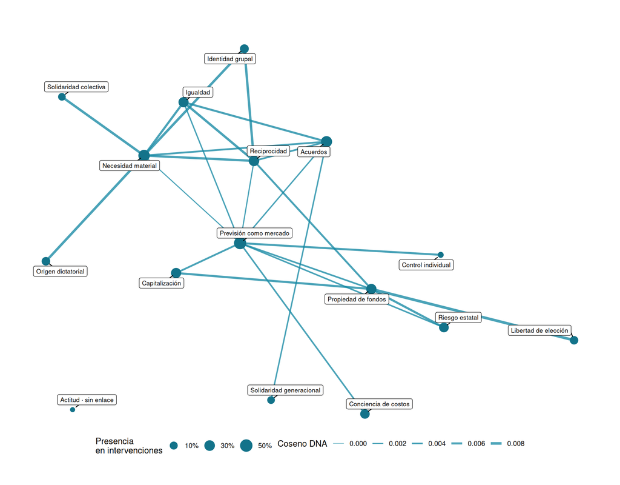

Figura 2: Red exploratoria de congruencia entre los 16 conceptos, Ley 21.735

```r
p_congruence <- ggplot() +
  geom_segment(data = plot_edges,
               aes(x = x_from, y = y_from, xend = x_to, yend = y_to,
                   linewidth = coseno_DNA), color = "#1889A4", alpha = 0.78) +
  geom_point(data = nodes, aes(x = x, y = y, size = proporcion),
             color = "#13738A") +
  ggrepel::geom_label_repel(data = nodes,
                            aes(x = x, y = y, label = network_label),
                            size = 2.8, max.overlaps = Inf, seed = 20260922,
                            box.padding = 0.35, point.padding = 0.3,
                            fill = "white", label.size = 0.15,
                            min.segment.length = 0) +
  scale_linewidth(range = c(0.25, 1.6),
                  limits = c(0, max(plot_edges$coseno_DNA)),
                  labels = label_number(accuracy = 0.001)) +
  scale_size_continuous(range = c(2, 7), limits = c(0, 0.55),
                        breaks = c(0.1, 0.3, 0.5),
                        labels = label_percent(accuracy = 1)) +
  coord_equal(clip = "off") +
  labs(linewidth = "Coseno DNA", size = "Presencia\nen intervenciones") +
  theme_void() +
  theme(legend.position = "bottom",
        plot.background = element_rect(fill = "white", color = NA),
        plot.margin = margin(15, 25, 15, 25))
print(p_congruence)
ggsave(file.path(FIGURE_DIR, "red_congruencia.png"), p_congruence,
       width = 11, height = 8.6, dpi = 180, bg = "white")
```

La figura permite explorar la hipótesis de dos economías morales. Acuerdos y reciprocidad contributiva aparecen conectados con conceptos de ambos lados; su papel de puente es una lectura descriptiva, sin una medida formal de intermediación ni revisión de todas las declaraciones.

## Archivos reproducibles y límites

Las dos tablas se exportan a Word. Guardamos además las cifras de base y todos los pares de conceptos en Parquet; las rutas se reemplazan en cada ejecución.

```r
arrow::write_parquet(prevalence_law,
                     file.path(OUTPUT_DIR, "prevalencia_por_ley.parquet"))
arrow::write_parquet(pairs,
                     file.path(OUTPUT_DIR, "red_congruencia_pares.parquet"))
arrow::write_parquet(denominator_table,
                     file.path(OUTPUT_DIR, "denominadores.parquet"))
arrow::write_parquet(stance_counts,
                     file.path(OUTPUT_DIR, "posturas_por_concepto_ley.parquet"))
```

La revisión de calidad de las anotaciones, una prueba de sensibilidad por proveedor, la desagregación temporal de la red y una versión con nodos concepto–postura quedan como pasos de validación. El análisis de comunidades Spin Glass no forma parte de estos resultados.

## Referencia metodológica

La binarización y la normalización por coseno se contrastaron con el texto original de (Leifeld 2017), el ejemplo local `example/discourse_networks.R` y el [código fuente del paquete DNA](https://github.com/leifeld-lab/dna).

## Referencias

Leifeld, Philip. 2017. «Discourse Network Analysis: Policy Debates as Dynamic Networks». En *The Oxford Handbook of Political Networks*, editado por Jennifer Nicoll Victor, Alexander H. Montgomery, y Mark Lubell. Oxford University Press. https://doi.org/10.1093/oxfordhb/9780190228217.013.25.